# Risk Factor Analysis

## Outcome Variable

**Outcome Variable:** y_rate_len

## Predictor Variables

**Intervention Variable:** cleanck

**Adjustment Set:**

unadjusted

## Stratifying Variables

The analysis was stratified on these variable(s):

- agecat
- studyid
- country

## Data Summary

| agecat | studyid | country | cleanck | n_cell | n |
| --- | --- | --- | --- | --- | --- |
| 0-3 months | CMC-V-BCS-2002 | INDIA | 1 | 40 | 88 |
| 0-3 months | CMC-V-BCS-2002 | INDIA | 0 | 48 | 88 |
| 0-3 months | GMS-Nepal | NEPAL | 1 | 6 | 460 |
| 0-3 months | GMS-Nepal | NEPAL | 0 | 454 | 460 |
| 0-3 months | IRC | INDIA | 1 | 212 | 369 |
| 0-3 months | IRC | INDIA | 0 | 157 | 369 |
| 0-3 months | MAL-ED | PERU | 1 | 1 | 1 |
| 0-3 months | MAL-ED | PERU | 0 | 0 | 1 |
| 0-3 months | MAL-ED | SOUTH AFRICA | 1 | 1 | 2 |
| 0-3 months | MAL-ED | SOUTH AFRICA | 0 | 1 | 2 |
| 0-3 months | NIH-Crypto | BANGLADESH | 1 | 334 | 547 |
| 0-3 months | NIH-Crypto | BANGLADESH | 0 | 213 | 547 |
| 0-3 months | PROVIDE | BANGLADESH | 1 | 529 | 640 |
| 0-3 months | PROVIDE | BANGLADESH | 0 | 111 | 640 |
| 3-6 months | CMC-V-BCS-2002 | INDIA | 1 | 133 | 307 |
| 3-6 months | CMC-V-BCS-2002 | INDIA | 0 | 174 | 307 |
| 3-6 months | GMS-Nepal | NEPAL | 1 | 6 | 424 |
| 3-6 months | GMS-Nepal | NEPAL | 0 | 418 | 424 |
| 3-6 months | IRC | INDIA | 1 | 224 | 390 |
| 3-6 months | IRC | INDIA | 0 | 166 | 390 |
| 3-6 months | MAL-ED | SOUTH AFRICA | 1 | 1 | 1 |
| 3-6 months | MAL-ED | SOUTH AFRICA | 0 | 0 | 1 |
| 3-6 months | NIH-Crypto | BANGLADESH | 1 | 315 | 527 |
| 3-6 months | NIH-Crypto | BANGLADESH | 0 | 212 | 527 |
| 3-6 months | PROVIDE | BANGLADESH | 1 | 492 | 598 |
| 3-6 months | PROVIDE | BANGLADESH | 0 | 106 | 598 |
| 6-9 months | CMC-V-BCS-2002 | INDIA | 1 | 136 | 313 |
| 6-9 months | CMC-V-BCS-2002 | INDIA | 0 | 177 | 313 |
| 6-9 months | GMS-Nepal | NEPAL | 1 | 8 | 433 |
| 6-9 months | GMS-Nepal | NEPAL | 0 | 425 | 433 |

[output cut: 68 more lines]

The following strata were considered:

- agecat: 0-3 months, studyid: CMC-V-BCS-2002, country: INDIA
- agecat: 0-3 months, studyid: GMS-Nepal, country: NEPAL
- agecat: 0-3 months, studyid: IRC, country: INDIA
- agecat: 0-3 months, studyid: MAL-ED, country: PERU
- agecat: 0-3 months, studyid: MAL-ED, country: SOUTH AFRICA
- agecat: 0-3 months, studyid: NIH-Crypto, country: BANGLADESH
- agecat: 0-3 months, studyid: PROVIDE, country: BANGLADESH
- agecat: 12-15 months, studyid: CMC-V-BCS-2002, country: INDIA
- agecat: 12-15 months, studyid: GMS-Nepal, country: NEPAL
- agecat: 12-15 months, studyid: IRC, country: INDIA
- agecat: 12-15 months, studyid: MAL-ED, country: SOUTH AFRICA
- agecat: 12-15 months, studyid: NIH-Crypto, country: BANGLADESH
- agecat: 12-15 months, studyid: PROVIDE, country: BANGLADESH
- agecat: 15-18 months, studyid: CMC-V-BCS-2002, country: INDIA
- agecat: 15-18 months, studyid: GMS-Nepal, country: NEPAL
- agecat: 15-18 months, studyid: IRC, country: INDIA
- agecat: 15-18 months, studyid: MAL-ED, country: SOUTH AFRICA
- agecat: 15-18 months, studyid: NIH-Crypto, country: BANGLADESH
- agecat: 15-18 months, studyid: PROVIDE, country: BANGLADESH
- agecat: 18-21 months, studyid: CMC-V-BCS-2002, country: INDIA
- agecat: 18-21 months, studyid: GMS-Nepal, country: NEPAL
- agecat: 18-21 months, studyid: IRC, country: INDIA
- agecat: 18-21 months, studyid: MAL-ED, country: SOUTH AFRICA
- agecat: 18-21 months, studyid: NIH-Crypto, country: BANGLADESH
- agecat: 18-21 months, studyid: PROVIDE, country: BANGLADESH
- agecat: 21-24 months, studyid: CMC-V-BCS-2002, country: INDIA
- agecat: 21-24 months, studyid: GMS-Nepal, country: NEPAL
- agecat: 21-24 months, studyid: IRC, country: INDIA
- agecat: 21-24 months, studyid: MAL-ED, country: SOUTH AFRICA
- agecat: 21-24 months, studyid: NIH-Crypto, country: BANGLADESH
- agecat: 21-24 months, studyid: PROVIDE, country: BANGLADESH
- agecat: 3-6 months, studyid: CMC-V-BCS-2002, country: INDIA
- agecat: 3-6 months, studyid: GMS-Nepal, country: NEPAL
- agecat: 3-6 months, studyid: IRC, country: INDIA
- agecat: 3-6 months, studyid: MAL-ED, country: SOUTH AFRICA
- agecat: 3-6 months, studyid: NIH-Crypto, country: BANGLADESH
- agecat: 3-6 months, studyid: PROVIDE, country: BANGLADESH
- agecat: 6-9 months, studyid: CMC-V-BCS-2002, country: INDIA
- agecat: 6-9 months, studyid: GMS-Nepal, country: NEPAL
- agecat: 6-9 months, studyid: IRC, country: INDIA
- agecat: 6-9 months, studyid: MAL-ED, country: SOUTH AFRICA
- agecat: 6-9 months, studyid: NIH-Crypto, country: BANGLADESH
- agecat: 6-9 months, studyid: PROVIDE, country: BANGLADESH
- agecat: 9-12 months, studyid: CMC-V-BCS-2002, country: INDIA
- agecat: 9-12 months, studyid: GMS-Nepal, country: NEPAL
- agecat: 9-12 months, studyid: IRC, country: INDIA
- agecat: 9-12 months, studyid: MAL-ED, country: SOUTH AFRICA
- agecat: 9-12 months, studyid: NIH-Crypto, country: BANGLADESH
- agecat: 9-12 months, studyid: PROVIDE, country: BANGLADESH

### Dropped Strata

Some strata were dropped due to rare outcomes:

- agecat: 0-3 months, studyid: MAL-ED, country: PERU
- agecat: 0-3 months, studyid: MAL-ED, country: SOUTH AFRICA
- agecat: 3-6 months, studyid: MAL-ED, country: SOUTH AFRICA
- agecat: 6-9 months, studyid: MAL-ED, country: SOUTH AFRICA
- agecat: 9-12 months, studyid: MAL-ED, country: SOUTH AFRICA
- agecat: 12-15 months, studyid: MAL-ED, country: SOUTH AFRICA
- agecat: 15-18 months, studyid: MAL-ED, country: SOUTH AFRICA
- agecat: 18-21 months, studyid: MAL-ED, country: SOUTH AFRICA
- agecat: 21-24 months, studyid: GMS-Nepal, country: NEPAL
- agecat: 21-24 months, studyid: MAL-ED, country: SOUTH AFRICA

## Methods Detail

We’re interested in the causal parameters $E[Y_a]$ for all values of $a \in \mathcal{A}$. These parameters represent the mean outcome if, possibly contrary to fact, we intervened to set all units to have $A=a$. Under the randomization and positivity assumptions, these are identified by the statistical parameters $\psi_a=E_W[E_{Y|A,W}(Y|A=a,W)]$. In addition, we’re interested in the mean of $Y$, $E[Y]$ under no intervention (the observed mean). We will estimate these parameters by using SuperLearner to fit the relevant likelihood factors – $E_{Y|A,W}(Y|A=a,W)$ and $p(A=a|W)$, and then updating our likelihood fit using a joint TMLE.

For unadjusted analyses ($W=\{\}$), initial likelihoods were estimated using Lrnr_glm to estimate the simple $E(Y|A)$ and Lrnr_mean to estimate $p(A)$. For adjusted analyses, a small library containing Lrnr_glmnet, Lrnr_xgboost, and Lrnr_mean was used.

Having estimated these parameters, we will then use the delta method to estimate relative risks and attributable risks relative to a prespecified baseline level of $A$.

# Results Detail

## Results Plots

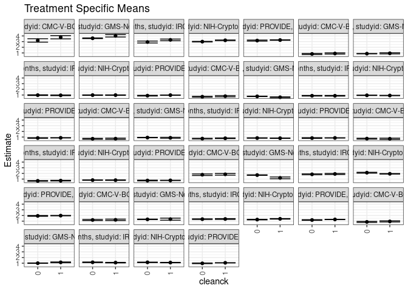

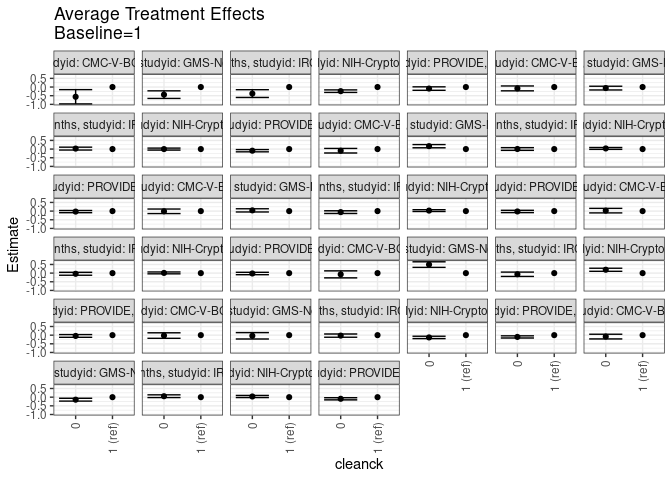

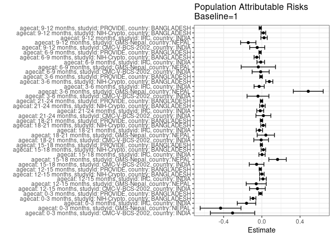

## Results Table

### Parameter: TSM

| agecat | studyid | country | intervention_level | baseline_level | estimate | ci_lower | ci_upper |
| --- | --- | --- | --- | --- | --- | --- | --- |
| 0-3 months | CMC-V-BCS-2002 | INDIA | 1 | NA | 3.7667853 | 3.4830196 | 4.0505511 |
| 0-3 months | CMC-V-BCS-2002 | INDIA | 0 | NA | 3.2046894 | 2.9056702 | 3.5037085 |
| 0-3 months | GMS-Nepal | NEPAL | 1 | NA | 4.0267398 | 3.8145010 | 4.2389786 |
| 0-3 months | GMS-Nepal | NEPAL | 0 | NA | 3.5890576 | 3.5338399 | 3.6442753 |
| 0-3 months | IRC | INDIA | 1 | NA | 3.3065344 | 3.1625748 | 3.4504940 |
| 0-3 months | IRC | INDIA | 0 | NA | 2.9292115 | 2.7578029 | 3.1006201 |
| 0-3 months | NIH-Crypto | BANGLADESH | 1 | NA | 3.2298846 | 3.1742841 | 3.2854852 |
| 0-3 months | NIH-Crypto | BANGLADESH | 0 | NA | 2.9921810 | 2.9435414 | 3.0408205 |
| 0-3 months | PROVIDE | BANGLADESH | 1 | NA | 3.2729429 | 3.2325979 | 3.3132879 |
| 0-3 months | PROVIDE | BANGLADESH | 0 | NA | 3.1849464 | 3.0936901 | 3.2762028 |
| 3-6 months | CMC-V-BCS-2002 | INDIA | 1 | NA | 1.8445040 | 1.6964825 | 1.9925255 |
| 3-6 months | CMC-V-BCS-2002 | INDIA | 0 | NA | 1.7726660 | 1.6356257 | 1.9097063 |
| 3-6 months | GMS-Nepal | NEPAL | 1 | NA | 1.2139650 | 1.0591458 | 1.3687842 |
| 3-6 months | GMS-Nepal | NEPAL | 0 | NA | 1.7068916 | 1.6642904 | 1.7494928 |
| 3-6 months | IRC | INDIA | 1 | NA | 1.9091738 | 1.8145918 | 2.0037558 |
| 3-6 months | IRC | INDIA | 0 | NA | 1.8424439 | 1.7603966 | 1.9244912 |
| 3-6 months | NIH-Crypto | BANGLADESH | 1 | NA | 1.9344184 | 1.8856905 | 1.9831463 |
| 3-6 months | NIH-Crypto | BANGLADESH | 0 | NA | 2.1286478 | 2.0540579 | 2.2032376 |
| 3-6 months | PROVIDE | BANGLADESH | 1 | NA | 1.9738979 | 1.9354749 | 2.0123210 |
| 3-6 months | PROVIDE | BANGLADESH | 0 | NA | 1.9279072 | 1.8596207 | 1.9961937 |
| 6-9 months | CMC-V-BCS-2002 | INDIA | 1 | NA | 1.2300818 | 1.1060763 | 1.3540873 |
| 6-9 months | CMC-V-BCS-2002 | INDIA | 0 | NA | 1.2075464 | 1.1090073 | 1.3060855 |
| 6-9 months | GMS-Nepal | NEPAL | 1 | NA | 1.3515781 | 1.1725495 | 1.5306067 |
| 6-9 months | GMS-Nepal | NEPAL | 0 | NA | 1.3140376 | 1.2691138 | 1.3589614 |
| 6-9 months | IRC | INDIA | 1 | NA | 1.3772629 | 1.3097258 | 1.4448000 |
| 6-9 months | IRC | INDIA | 0 | NA | 1.3497552 | 1.2842467 | 1.4152636 |
| 6-9 months | NIH-Crypto | BANGLADESH | 1 | NA | 1.4062592 | 1.3597295 | 1.4527888 |
| 6-9 months | NIH-Crypto | BANGLADESH | 0 | NA | 1.2750502 | 1.2253991 | 1.3247013 |
| 6-9 months | PROVIDE | BANGLADESH | 1 | NA | 1.3010098 | 1.2730891 | 1.3289305 |
| 6-9 months | PROVIDE | BANGLADESH | 0 | NA | 1.1990283 | 1.1428086 | 1.2552481 |
| 9-12 months | CMC-V-BCS-2002 | INDIA | 1 | NA | 0.9480654 | 0.8498165 | 1.0463143 |
| 9-12 months | CMC-V-BCS-2002 | INDIA | 0 | NA | 0.8648863 | 0.7724470 | 0.9573257 |
| 9-12 months | GMS-Nepal | NEPAL | 1 | NA | 1.1461261 | 1.0720811 | 1.2201711 |
| 9-12 months | GMS-Nepal | NEPAL | 0 | NA | 1.0011032 | 0.9653508 | 1.0368557 |
| 9-12 months | IRC | INDIA | 1 | NA | 1.0997657 | 1.0456039 | 1.1539275 |
| 9-12 months | IRC | INDIA | 0 | NA | 1.1550029 | 1.0970899 | 1.2129160 |
| 9-12 months | NIH-Crypto | BANGLADESH | 1 | NA | 1.1081579 | 1.0674861 | 1.1488296 |
| 9-12 months | NIH-Crypto | BANGLADESH | 0 | NA | 1.1473198 | 1.1033350 | 1.1913046 |
| 9-12 months | PROVIDE | BANGLADESH | 1 | NA | 1.0668363 | 1.0363335 | 1.0973390 |
| 9-12 months | PROVIDE | BANGLADESH | 0 | NA | 0.9732726 | 0.9197977 | 1.0267476 |
| 12-15 months | CMC-V-BCS-2002 | INDIA | 1 | NA | 0.8999063 | 0.7938439 | 1.0059686 |
| 12-15 months | CMC-V-BCS-2002 | INDIA | 0 | NA | 0.8205817 | 0.7286008 | 0.9125627 |
| 12-15 months | GMS-Nepal | NEPAL | 1 | NA | 0.9345104 | 0.8314399 | 1.0375809 |
| 12-15 months | GMS-Nepal | NEPAL | 0 | NA | 0.8742379 | 0.8427187 | 0.9057571 |
| 12-15 months | IRC | INDIA | 1 | NA | 0.9457616 | 0.8859983 | 1.0055249 |
| 12-15 months | IRC | INDIA | 0 | NA | 0.9734796 | 0.9154288 | 1.0315303 |
| 12-15 months | NIH-Crypto | BANGLADESH | 1 | NA | 0.9799791 | 0.9420406 | 1.0179177 |
| 12-15 months | NIH-Crypto | BANGLADESH | 0 | NA | 0.9793670 | 0.9365871 | 1.0221470 |
| 12-15 months | PROVIDE | BANGLADESH | 1 | NA | 0.9758930 | 0.9468976 | 1.0048884 |
| 12-15 months | PROVIDE | BANGLADESH | 0 | NA | 0.8815188 | 0.8237914 | 0.9392462 |
| 15-18 months | CMC-V-BCS-2002 | INDIA | 1 | NA | 0.7890603 | 0.6788335 | 0.8992870 |
| 15-18 months | CMC-V-BCS-2002 | INDIA | 0 | NA | 0.6938877 | 0.6211245 | 0.7666508 |
| 15-18 months | GMS-Nepal | NEPAL | 1 | NA | 0.5938125 | 0.5084972 | 0.6791279 |
| 15-18 months | GMS-Nepal | NEPAL | 0 | NA | 0.7611989 | 0.7229049 | 0.7994929 |
| 15-18 months | IRC | INDIA | 1 | NA | 0.8618767 | 0.8039429 | 0.9198105 |
| 15-18 months | IRC | INDIA | 0 | NA | 0.8658871 | 0.8142950 | 0.9174793 |
| 15-18 months | NIH-Crypto | BANGLADESH | 1 | NA | 0.9077237 | 0.8723230 | 0.9431245 |
| 15-18 months | NIH-Crypto | BANGLADESH | 0 | NA | 0.9436571 | 0.9045698 | 0.9827445 |
| 15-18 months | PROVIDE | BANGLADESH | 1 | NA | 0.8610050 | 0.8344517 | 0.8875583 |
| 15-18 months | PROVIDE | BANGLADESH | 0 | NA | 0.8322279 | 0.7753321 | 0.8891237 |
| 18-21 months | CMC-V-BCS-2002 | INDIA | 1 | NA | 0.7071820 | 0.6032625 | 0.8111015 |
| 18-21 months | CMC-V-BCS-2002 | INDIA | 0 | NA | 0.6948620 | 0.6146034 | 0.7751205 |
| 18-21 months | GMS-Nepal | NEPAL | 1 | NA | 0.8652948 | 0.7802558 | 0.9503338 |
| 18-21 months | GMS-Nepal | NEPAL | 0 | NA | 0.9075162 | 0.8701345 | 0.9448979 |
| 18-21 months | IRC | INDIA | 1 | NA | 0.7824952 | 0.7297810 | 0.8352094 |
| 18-21 months | IRC | INDIA | 0 | NA | 0.7224758 | 0.6666444 | 0.7783072 |
| 18-21 months | NIH-Crypto | BANGLADESH | 1 | NA | 0.7959424 | 0.7598608 | 0.8320241 |
| 18-21 months | NIH-Crypto | BANGLADESH | 0 | NA | 0.8246046 | 0.7872628 | 0.8619463 |
| 18-21 months | PROVIDE | BANGLADESH | 1 | NA | 0.8432154 | 0.8172540 | 0.8691768 |
| 18-21 months | PROVIDE | BANGLADESH | 0 | NA | 0.8222371 | 0.7612326 | 0.8832415 |
| 21-24 months | CMC-V-BCS-2002 | INDIA | 1 | NA | 0.6907861 | 0.5797808 | 0.8017914 |
| 21-24 months | CMC-V-BCS-2002 | INDIA | 0 | NA | 0.7178178 | 0.6477323 | 0.7879034 |
| 21-24 months | IRC | INDIA | 1 | NA | 0.7235019 | 0.6677553 | 0.7792485 |
| 21-24 months | IRC | INDIA | 0 | NA | 0.6844532 | 0.6216656 | 0.7472408 |
| 21-24 months | NIH-Crypto | BANGLADESH | 1 | NA | 0.8086764 | 0.7672377 | 0.8501151 |
| 21-24 months | NIH-Crypto | BANGLADESH | 0 | NA | 0.8200986 | 0.7855538 | 0.8546433 |
| 21-24 months | PROVIDE | BANGLADESH | 1 | NA | 0.7669422 | 0.7392503 | 0.7946341 |
| 21-24 months | PROVIDE | BANGLADESH | 0 | NA | 0.7456174 | 0.6825297 | 0.8087050 |

### Parameter: E(Y)

| agecat | studyid | country | intervention_level | baseline_level | estimate | ci_lower | ci_upper |
| --- | --- | --- | --- | --- | --- | --- | --- |
| 0-3 months | CMC-V-BCS-2002 | INDIA | NA | NA | 3.4601875 | 3.2440906 | 3.6762845 |
| 0-3 months | GMS-Nepal | NEPAL | NA | NA | 3.5947665 | 3.5404780 | 3.6490550 |
| 0-3 months | IRC | INDIA | NA | NA | 3.1459932 | 3.0340880 | 3.2578984 |
| 0-3 months | NIH-Crypto | BANGLADESH | NA | NA | 3.1373236 | 3.0972506 | 3.1773966 |
| 0-3 months | PROVIDE | BANGLADESH | NA | NA | 3.2576810 | 3.2206777 | 3.2946843 |
| 3-6 months | CMC-V-BCS-2002 | INDIA | NA | NA | 1.8037880 | 1.7029866 | 1.9045894 |
| 3-6 months | GMS-Nepal | NEPAL | NA | NA | 1.6999162 | 1.6578328 | 1.7419997 |
| 3-6 months | IRC | INDIA | NA | NA | 1.8807708 | 1.8161067 | 1.9454349 |
| 3-6 months | NIH-Crypto | BANGLADESH | NA | NA | 2.0125524 | 1.9699507 | 2.0551541 |
| 3-6 months | PROVIDE | BANGLADESH | NA | NA | 1.9657457 | 1.9318660 | 1.9996254 |
| 6-9 months | CMC-V-BCS-2002 | INDIA | NA | NA | 1.2173381 | 1.1398153 | 1.2948610 |
| 6-9 months | GMS-Nepal | NEPAL | NA | NA | 1.3147312 | 1.2706998 | 1.3587625 |
| 6-9 months | IRC | INDIA | NA | NA | 1.3656516 | 1.3178011 | 1.4135021 |
| 6-9 months | NIH-Crypto | BANGLADESH | NA | NA | 1.3527759 | 1.3181375 | 1.3874142 |
| 6-9 months | PROVIDE | BANGLADESH | NA | NA | 1.2824185 | 1.2571827 | 1.3076542 |
| 9-12 months | CMC-V-BCS-2002 | INDIA | NA | NA | 0.8995224 | 0.8316661 | 0.9673787 |
| 9-12 months | GMS-Nepal | NEPAL | NA | NA | 1.0038395 | 0.9688811 | 1.0387978 |
| 9-12 months | IRC | INDIA | NA | NA | 1.1229343 | 1.0831083 | 1.1627603 |
| 9-12 months | NIH-Crypto | BANGLADESH | NA | NA | 1.1243367 | 1.0942919 | 1.1543816 |
| 9-12 months | PROVIDE | BANGLADESH | NA | NA | 1.0499750 | 1.0230130 | 1.0769370 |
| 12-15 months | CMC-V-BCS-2002 | INDIA | NA | NA | 0.8533724 | 0.7837188 | 0.9230260 |
| 12-15 months | GMS-Nepal | NEPAL | NA | NA | 0.8753778 | 0.8445288 | 0.9062268 |
| 12-15 months | IRC | INDIA | NA | NA | 0.9574323 | 0.9150475 | 0.9998172 |
| 12-15 months | NIH-Crypto | BANGLADESH | NA | NA | 0.9797232 | 0.9513105 | 1.0081359 |
| 12-15 months | PROVIDE | BANGLADESH | NA | NA | 0.9597501 | 0.9335899 | 0.9859102 |
| 15-18 months | CMC-V-BCS-2002 | INDIA | NA | NA | 0.7339135 | 0.6710399 | 0.7967871 |
| 15-18 months | GMS-Nepal | NEPAL | NA | NA | 0.7581134 | 0.7206558 | 0.7955710 |
| 15-18 months | IRC | INDIA | NA | NA | 0.8635602 | 0.8235728 | 0.9035477 |
| 15-18 months | NIH-Crypto | BANGLADESH | NA | NA | 0.9239169 | 0.8976277 | 0.9502061 |
| 15-18 months | PROVIDE | BANGLADESH | NA | NA | 0.8560998 | 0.8320145 | 0.8801852 |
| 18-21 months | CMC-V-BCS-2002 | INDIA | NA | NA | 0.6999920 | 0.6362204 | 0.7637635 |
| 18-21 months | GMS-Nepal | NEPAL | NA | NA | 0.9067882 | 0.8702752 | 0.9433012 |
| 18-21 months | IRC | INDIA | NA | NA | 0.7567726 | 0.7181843 | 0.7953609 |
| 18-21 months | NIH-Crypto | BANGLADESH | NA | NA | 0.8098412 | 0.7838581 | 0.8358244 |
| 18-21 months | PROVIDE | BANGLADESH | NA | NA | 0.8393377 | 0.8153485 | 0.8633269 |
| 21-24 months | CMC-V-BCS-2002 | INDIA | NA | NA | 0.7068472 | 0.6454809 | 0.7682134 |
| 21-24 months | IRC | INDIA | NA | NA | 0.7066493 | 0.6649098 | 0.7483888 |
| 21-24 months | NIH-Crypto | BANGLADESH | NA | NA | 0.8147508 | 0.7880257 | 0.8414758 |
| 21-24 months | PROVIDE | BANGLADESH | NA | NA | 0.7631391 | 0.7377453 | 0.7885328 |

### Parameter: ATE

| agecat | studyid | country | intervention_level | baseline_level | estimate | ci_lower | ci_upper |
| --- | --- | --- | --- | --- | --- | --- | --- |
| 0-3 months | CMC-V-BCS-2002 | INDIA | 1 | 1 | 0.0000000 | 0.0000000 | 0.0000000 |
| 0-3 months | CMC-V-BCS-2002 | INDIA | 0 | 1 | -0.5620960 | -0.9743283 | -0.1498637 |
| 0-3 months | GMS-Nepal | NEPAL | 1 | 1 | 0.0000000 | 0.0000000 | 0.0000000 |
| 0-3 months | GMS-Nepal | NEPAL | 0 | 1 | -0.4376822 | -0.6569863 | -0.2183781 |
| 0-3 months | IRC | INDIA | 1 | 1 | 0.0000000 | 0.0000000 | 0.0000000 |
| 0-3 months | IRC | INDIA | 0 | 1 | -0.3773229 | -0.6011650 | -0.1534808 |
| 0-3 months | NIH-Crypto | BANGLADESH | 1 | 1 | 0.0000000 | 0.0000000 | 0.0000000 |
| 0-3 months | NIH-Crypto | BANGLADESH | 0 | 1 | -0.2377037 | -0.3115767 | -0.1638306 |
| 0-3 months | PROVIDE | BANGLADESH | 1 | 1 | 0.0000000 | 0.0000000 | 0.0000000 |
| 0-3 months | PROVIDE | BANGLADESH | 0 | 1 | -0.0879965 | -0.1877735 | 0.0117805 |
| 3-6 months | CMC-V-BCS-2002 | INDIA | 1 | 1 | 0.0000000 | 0.0000000 | 0.0000000 |
| 3-6 months | CMC-V-BCS-2002 | INDIA | 0 | 1 | -0.0718380 | -0.2735566 | 0.1298807 |
| 3-6 months | GMS-Nepal | NEPAL | 1 | 1 | 0.0000000 | 0.0000000 | 0.0000000 |
| 3-6 months | GMS-Nepal | NEPAL | 0 | 1 | 0.4929266 | 0.3323531 | 0.6535001 |
| 3-6 months | IRC | INDIA | 1 | 1 | 0.0000000 | 0.0000000 | 0.0000000 |
| 3-6 months | IRC | INDIA | 0 | 1 | -0.0667299 | -0.1919398 | 0.0584800 |
| 3-6 months | NIH-Crypto | BANGLADESH | 1 | 1 | 0.0000000 | 0.0000000 | 0.0000000 |
| 3-6 months | NIH-Crypto | BANGLADESH | 0 | 1 | 0.1942293 | 0.1051336 | 0.2833251 |
| 3-6 months | PROVIDE | BANGLADESH | 1 | 1 | 0.0000000 | 0.0000000 | 0.0000000 |
| 3-6 months | PROVIDE | BANGLADESH | 0 | 1 | -0.0459907 | -0.1243449 | 0.0323635 |
| 6-9 months | CMC-V-BCS-2002 | INDIA | 1 | 1 | 0.0000000 | 0.0000000 | 0.0000000 |
| 6-9 months | CMC-V-BCS-2002 | INDIA | 0 | 1 | -0.0225354 | -0.1809252 | 0.1358544 |
| 6-9 months | GMS-Nepal | NEPAL | 1 | 1 | 0.0000000 | 0.0000000 | 0.0000000 |
| 6-9 months | GMS-Nepal | NEPAL | 0 | 1 | -0.0375405 | -0.2221194 | 0.1470385 |
| 6-9 months | IRC | INDIA | 1 | 1 | 0.0000000 | 0.0000000 | 0.0000000 |
| 6-9 months | IRC | INDIA | 0 | 1 | -0.0275077 | -0.1215960 | 0.0665807 |
| 6-9 months | NIH-Crypto | BANGLADESH | 1 | 1 | 0.0000000 | 0.0000000 | 0.0000000 |
| 6-9 months | NIH-Crypto | BANGLADESH | 0 | 1 | -0.1312090 | -0.1992548 | -0.0631631 |
| 6-9 months | PROVIDE | BANGLADESH | 1 | 1 | 0.0000000 | 0.0000000 | 0.0000000 |
| 6-9 months | PROVIDE | BANGLADESH | 0 | 1 | -0.1019815 | -0.1647527 | -0.0392102 |
| 9-12 months | CMC-V-BCS-2002 | INDIA | 1 | 1 | 0.0000000 | 0.0000000 | 0.0000000 |
| 9-12 months | CMC-V-BCS-2002 | INDIA | 0 | 1 | -0.0831791 | -0.2180786 | 0.0517204 |
| 9-12 months | GMS-Nepal | NEPAL | 1 | 1 | 0.0000000 | 0.0000000 | 0.0000000 |
| 9-12 months | GMS-Nepal | NEPAL | 0 | 1 | -0.1450229 | -0.2272476 | -0.0627982 |
| 9-12 months | IRC | INDIA | 1 | 1 | 0.0000000 | 0.0000000 | 0.0000000 |
| 9-12 months | IRC | INDIA | 0 | 1 | 0.0552372 | -0.0240561 | 0.1345305 |
| 9-12 months | NIH-Crypto | BANGLADESH | 1 | 1 | 0.0000000 | 0.0000000 | 0.0000000 |
| 9-12 months | NIH-Crypto | BANGLADESH | 0 | 1 | 0.0391620 | -0.0207451 | 0.0990690 |
| 9-12 months | PROVIDE | BANGLADESH | 1 | 1 | 0.0000000 | 0.0000000 | 0.0000000 |
| 9-12 months | PROVIDE | BANGLADESH | 0 | 1 | -0.0935637 | -0.1551265 | -0.0320008 |
| 12-15 months | CMC-V-BCS-2002 | INDIA | 1 | 1 | 0.0000000 | 0.0000000 | 0.0000000 |
| 12-15 months | CMC-V-BCS-2002 | INDIA | 0 | 1 | -0.0793245 | -0.2197158 | 0.0610667 |
| 12-15 months | GMS-Nepal | NEPAL | 1 | 1 | 0.0000000 | 0.0000000 | 0.0000000 |
| 12-15 months | GMS-Nepal | NEPAL | 0 | 1 | -0.0602725 | -0.1680547 | 0.0475096 |
| 12-15 months | IRC | INDIA | 1 | 1 | 0.0000000 | 0.0000000 | 0.0000000 |
| 12-15 months | IRC | INDIA | 0 | 1 | 0.0277180 | -0.0555979 | 0.1110339 |
| 12-15 months | NIH-Crypto | BANGLADESH | 1 | 1 | 0.0000000 | 0.0000000 | 0.0000000 |
| 12-15 months | NIH-Crypto | BANGLADESH | 0 | 1 | -0.0006121 | -0.0577913 | 0.0565670 |
| 12-15 months | PROVIDE | BANGLADESH | 1 | 1 | 0.0000000 | 0.0000000 | 0.0000000 |
| 12-15 months | PROVIDE | BANGLADESH | 0 | 1 | -0.0943742 | -0.1589744 | -0.0297740 |
| 15-18 months | CMC-V-BCS-2002 | INDIA | 1 | 1 | 0.0000000 | 0.0000000 | 0.0000000 |
| 15-18 months | CMC-V-BCS-2002 | INDIA | 0 | 1 | -0.0951726 | -0.2272499 | 0.0369047 |
| 15-18 months | GMS-Nepal | NEPAL | 1 | 1 | 0.0000000 | 0.0000000 | 0.0000000 |
| 15-18 months | GMS-Nepal | NEPAL | 0 | 1 | 0.1673863 | 0.0738709 | 0.2609018 |
| 15-18 months | IRC | INDIA | 1 | 1 | 0.0000000 | 0.0000000 | 0.0000000 |
| 15-18 months | IRC | INDIA | 0 | 1 | 0.0040104 | -0.0735658 | 0.0815867 |
| 15-18 months | NIH-Crypto | BANGLADESH | 1 | 1 | 0.0000000 | 0.0000000 | 0.0000000 |
| 15-18 months | NIH-Crypto | BANGLADESH | 0 | 1 | 0.0359334 | -0.0168021 | 0.0886689 |
| 15-18 months | PROVIDE | BANGLADESH | 1 | 1 | 0.0000000 | 0.0000000 | 0.0000000 |
| 15-18 months | PROVIDE | BANGLADESH | 0 | 1 | -0.0287771 | -0.0915642 | 0.0340099 |
| 18-21 months | CMC-V-BCS-2002 | INDIA | 1 | 1 | 0.0000000 | 0.0000000 | 0.0000000 |
| 18-21 months | CMC-V-BCS-2002 | INDIA | 0 | 1 | -0.0123200 | -0.1436239 | 0.1189838 |
| 18-21 months | GMS-Nepal | NEPAL | 1 | 1 | 0.0000000 | 0.0000000 | 0.0000000 |
| 18-21 months | GMS-Nepal | NEPAL | 0 | 1 | 0.0422214 | -0.0506711 | 0.1351139 |
| 18-21 months | IRC | INDIA | 1 | 1 | 0.0000000 | 0.0000000 | 0.0000000 |
| 18-21 months | IRC | INDIA | 0 | 1 | -0.0600194 | -0.1368044 | 0.0167655 |
| 18-21 months | NIH-Crypto | BANGLADESH | 1 | 1 | 0.0000000 | 0.0000000 | 0.0000000 |
| 18-21 months | NIH-Crypto | BANGLADESH | 0 | 1 | 0.0286621 | -0.0232637 | 0.0805879 |
| 18-21 months | PROVIDE | BANGLADESH | 1 | 1 | 0.0000000 | 0.0000000 | 0.0000000 |
| 18-21 months | PROVIDE | BANGLADESH | 0 | 1 | -0.0209783 | -0.0872771 | 0.0453205 |
| 21-24 months | CMC-V-BCS-2002 | INDIA | 1 | 1 | 0.0000000 | 0.0000000 | 0.0000000 |
| 21-24 months | CMC-V-BCS-2002 | INDIA | 0 | 1 | 0.0270317 | -0.1042473 | 0.1583106 |
| 21-24 months | IRC | INDIA | 1 | 1 | 0.0000000 | 0.0000000 | 0.0000000 |
| 21-24 months | IRC | INDIA | 0 | 1 | -0.0390487 | -0.1230128 | 0.0449154 |
| 21-24 months | NIH-Crypto | BANGLADESH | 1 | 1 | 0.0000000 | 0.0000000 | 0.0000000 |
| 21-24 months | NIH-Crypto | BANGLADESH | 0 | 1 | 0.0114221 | -0.0425270 | 0.0653713 |
| 21-24 months | PROVIDE | BANGLADESH | 1 | 1 | 0.0000000 | 0.0000000 | 0.0000000 |
| 21-24 months | PROVIDE | BANGLADESH | 0 | 1 | -0.0213248 | -0.0902225 | 0.0475729 |

### Parameter: PAR

| agecat | studyid | country | intervention_level | baseline_level | estimate | ci_lower | ci_upper |
| --- | --- | --- | --- | --- | --- | --- | --- |
| 0-3 months | CMC-V-BCS-2002 | INDIA | 1 | NA | -0.3065978 | -0.5390159 | -0.0741797 |
| 0-3 months | GMS-Nepal | NEPAL | 1 | NA | -0.4319733 | -0.6458430 | -0.2181035 |
| 0-3 months | IRC | INDIA | 1 | NA | -0.1605412 | -0.2576688 | -0.0634136 |
| 0-3 months | NIH-Crypto | BANGLADESH | 1 | NA | -0.0925610 | -0.1229255 | -0.0621966 |
| 0-3 months | PROVIDE | BANGLADESH | 1 | NA | -0.0152619 | -0.0327587 | 0.0022349 |
| 3-6 months | CMC-V-BCS-2002 | INDIA | 1 | NA | -0.0407160 | -0.1551147 | 0.0736827 |
| 3-6 months | GMS-Nepal | NEPAL | 1 | NA | 0.4859512 | 0.3292938 | 0.6426086 |
| 3-6 months | IRC | INDIA | 1 | NA | -0.0284030 | -0.0817982 | 0.0249922 |
| 3-6 months | NIH-Crypto | BANGLADESH | 1 | NA | 0.0781340 | 0.0413803 | 0.1148877 |
| 3-6 months | PROVIDE | BANGLADESH | 1 | NA | -0.0081522 | -0.0221123 | 0.0058079 |
| 6-9 months | CMC-V-BCS-2002 | INDIA | 1 | NA | -0.0127437 | -0.1023209 | 0.0768336 |
| 6-9 months | GMS-Nepal | NEPAL | 1 | NA | -0.0368469 | -0.2168120 | 0.1431182 |
| 6-9 months | IRC | INDIA | 1 | NA | -0.0116113 | -0.0513495 | 0.0281269 |
| 6-9 months | NIH-Crypto | BANGLADESH | 1 | NA | -0.0534833 | -0.0817641 | -0.0252025 |
| 6-9 months | PROVIDE | BANGLADESH | 1 | NA | -0.0185913 | -0.0304870 | -0.0066956 |
| 9-12 months | CMC-V-BCS-2002 | INDIA | 1 | NA | -0.0485430 | -0.1273996 | 0.0303136 |
| 9-12 months | GMS-Nepal | NEPAL | 1 | NA | -0.1422866 | -0.2224777 | -0.0620955 |
| 9-12 months | IRC | INDIA | 1 | NA | 0.0231686 | -0.0101998 | 0.0565370 |
| 9-12 months | NIH-Crypto | BANGLADESH | 1 | NA | 0.0161789 | -0.0086261 | 0.0409839 |
| 9-12 months | PROVIDE | BANGLADESH | 1 | NA | -0.0168613 | -0.0283451 | -0.0053775 |
| 12-15 months | CMC-V-BCS-2002 | INDIA | 1 | NA | -0.0465338 | -0.1289995 | 0.0359318 |
| 12-15 months | GMS-Nepal | NEPAL | 1 | NA | -0.0591326 | -0.1642231 | 0.0459579 |
| 12-15 months | IRC | INDIA | 1 | NA | 0.0116707 | -0.0234367 | 0.0467782 |
| 12-15 months | NIH-Crypto | BANGLADESH | 1 | NA | -0.0002560 | -0.0241652 | 0.0236533 |
| 12-15 months | PROVIDE | BANGLADESH | 1 | NA | -0.0161430 | -0.0275989 | -0.0046870 |
| 15-18 months | CMC-V-BCS-2002 | INDIA | 1 | NA | -0.0551467 | -0.1318504 | 0.0215570 |
| 15-18 months | GMS-Nepal | NEPAL | 1 | NA | 0.1643009 | 0.0730987 | 0.2555031 |
| 15-18 months | IRC | INDIA | 1 | NA | 0.0016835 | -0.0308825 | 0.0342496 |
| 15-18 months | NIH-Crypto | BANGLADESH | 1 | NA | 0.0161932 | -0.0076273 | 0.0400136 |
| 15-18 months | PROVIDE | BANGLADESH | 1 | NA | -0.0049052 | -0.0156473 | 0.0058369 |
| 18-21 months | CMC-V-BCS-2002 | INDIA | 1 | NA | -0.0071900 | -0.0838229 | 0.0694428 |
| 18-21 months | GMS-Nepal | NEPAL | 1 | NA | 0.0414934 | -0.0490784 | 0.1320652 |
| 18-21 months | IRC | INDIA | 1 | NA | -0.0257226 | -0.0587693 | 0.0073241 |
| 18-21 months | NIH-Crypto | BANGLADESH | 1 | NA | 0.0138988 | -0.0113174 | 0.0391150 |
| 18-21 months | PROVIDE | BANGLADESH | 1 | NA | -0.0038777 | -0.0161518 | 0.0083964 |
| 21-24 months | CMC-V-BCS-2002 | INDIA | 1 | NA | 0.0160610 | -0.0619533 | 0.0940753 |
| 21-24 months | IRC | INDIA | 1 | NA | -0.0168526 | -0.0531420 | 0.0194368 |
| 21-24 months | NIH-Crypto | BANGLADESH | 1 | NA | 0.0060744 | -0.0226217 | 0.0347704 |
| 21-24 months | PROVIDE | BANGLADESH | 1 | NA | -0.0038032 | -0.0161128 | 0.0085065 |